# Installation of SNAP and NetworkX

- **Recomended**: [Anaconda Scientific Python Distribution](https://store.continuum.io/cshop/anaconda/) is the preferred and easiest way to enjoy python and its applications on data analysis, including social network data analysis, using python packages like [SNAP](http://snap.stanford.edu/snap/) and [NetworkX](https://networkx.github.io/). Anaconda already integrate [most popular Python packages](http://docs.continuum.io/anaconda/pkg-docs.html) for science, math, engineering, data analysis, including NetworkX, so it saves you a lot of time figuring out all the dependency of python packages and installing them one by one in order.
- Installation steps:
  1. [Download Anaconda](http://continuum.io/downloads), select the correct version corresponds to your OS by clicking the icons after **CHOOSE YOUR INSTALLER**, there are also installation tips in each OS version shower in the window.
  2. After the installation of Anaconda, you already have Python, Ipython, [Ipython Notebook](https://www.youtube.com/watch?feature=player_embedded&v=H6dLGQw9yFQ), NetworkX, which are the things we will use in this course.
  3. Suppose you installation path of Anaconda is "*AnacondaPath*", inside "*AnacondaPath/bin/*" folder there are commands like python, ipython, you can enter python either by clicking them or by running "AnacondaPath/bin/python" in your terminal, also you should be able to import networkx package. For example, in my computer(Linux),

     ```
     [rzheng@SymLab ~]$ ./workspace/anaconda-2.1.0/bin/python
     Python 2.7.8 |Anaconda 2.1.0 (64-bit)| (default, Aug 21 2014, 18:22:21)
     [GCC 4.4.7 20120313 (Red Hat 4.4.7-1)] on linux2
     Type "help", "copyright", "credits" or "license" for more information.
     Anaconda is brought to you by Continuum Analytics.
     Please check out: http://continuum.io/thanks and https://binstar.org
     >>> import networkx
     >>>
     ```

  4. Ipython Notebook is highly recommended for the purpose of education and self-learning, it enables an interactive experience of using python, and it uses web browser for the rendering of all the intermediate steps including your code snippets and results so you can share your notebooks/experiences with others. For example, in my computer, firefox (my default web browser) will be opened and i can create new notebook and run python codes based on the browser after running the following bash commands.

     ```
     [rzheng@SymLab tmp]$ ~/workspace/anaconda-2.1.0/bin/ipython notebook
     2015-02-08 17:24:39.561 [NotebookApp] Using existing profile dir: u'/home/rzheng/.ipython/profile_default'
     2015-02-08 17:24:39.570 [NotebookApp] Using MathJax from CDN: https://cdn.mathjax.org/mathjax/latest/MathJax.js
     2015-02-08 17:24:39.612 [NotebookApp] Serving notebooks from local directory: /home/rzheng/tmp
     2015-02-08 17:24:39.613 [NotebookApp] 0 active kernels
     2015-02-08 17:24:39.613 [NotebookApp] The IPython Notebook is running at: http://localhost:8888/
     2015-02-08 17:24:39.613 [NotebookApp] Use Control-C to stop this server and shut down all kernels (twice to skip confirmation).
     ```

  5. SNAP is not included in Anaconda, so we have to install its python bindings by ourselves, but it's easy. [Download](http://snap.stanford.edu/snappy/release/) the right version for your OS, unzip it, and then install it using the python inside Anaconda, instead of the python integrated by your OS. For example, in linux,

     ```
     [rzheng@SymLab workspace]$ wget http://snap.stanford.edu/snappy/release/snap-1.1-2.3-centos6.5-x64-py2.6.tar.gz
     [rzheng@SymLab workspace]$ tar zxvf snap-1.1-2.3-centos6.5-x64-py2.6.tar.gz
     [rzheng@SymLab workspace]$ cd snap-1.1-2.3-centos6.5-x64-py2.6
     [rzheng@SymLab snap-1.1-2.3-centos6.5-x64-py2.6]$ ~/workspace/anaconda-2.1.0/bin/python setup.py install
     [rzheng@SymLab snap-1.1-2.3-centos6.5-x64-py2.6]$ ~/workspace/anaconda-2.1.0/bin/python
     Python 2.7.8 |Anaconda 2.1.0 (64-bit)| (default, Aug 21 2014, 18:22:21)
     [GCC 4.4.7 20120313 (Red Hat 4.4.7-1)] on linux2
     Type "help", "copyright", "credits" or "license" for more information.
     Anaconda is brought to you by Continuum Analytics.
     Please check out: http://continuum.io/thanks and https://binstar.org
     >>> import networkx
     >>> import snap
     >>>
     ```

# NetworkX Tutorial

### Links

- [Gallery](http://networkx.github.io/documentation/latest/gallery.html)
- [Examples](http://networkx.github.io/documentation/latest/examples/)
- [Reference](http://networkx.github.io/documentation/latest/reference/index.html)
- [Documentation](http://networkx.github.io/documentation/networkx-1.9.1/#)

```python
# Simple example
import networkx as nx     # nx can be seemed as an alias of networkx module
G = nx.Graph()            # create an empty graph with no nodes and no edges
print G.nodes(), G.edges()
```

```
[] []
```

```python
G.add_node(1)    # add a single node
print G.nodes()
```

```
[1]
```

```python
G.add_nodes_from([2,3])    # add a list of nodes
print G.nodes()
```

```
[1, 2, 3]
```

```python
G.clear(); G.add_node(1)    # clear the graph and add a node
H = nx.path_graph(10)  # generate a bunch of nodes
print H
G.add_nodes_from(H)    # add all the nodes in H, repeated nodes "1" will not be added again
print G.nodes()
G.add_node(H)          # add H as a node of the graph
print G.nodes()
```

```
path_graph(10)
[0, 1, 2, 3, 4, 5, 6, 7, 8, 9]
[0, 1, 2, 3, 4, 5, 6, 7, 8, 9, <networkx.classes.graph.Graph object at 0x2a8ccd0>]
```

```python
G.add_edge(1,2)
print G.nodes(), G.edges()
```

```
[0, 1, 2, 3, 4, 5, 6, 7, 8, 9, <networkx.classes.graph.Graph object at 0x2a8ccd0>] [(1, 2)]
```

```python
e=(2,3)
G.add_edge(*e) # unpack edge tuple
print G.edges()
```

```
[(1, 2), (2, 3)]
```

```python
G.remove_edges_from(G.edges())  # clear edges
print G.edges()
G.add_edges_from([(1,2), (1,3)]) # add edges from a edge list
print G.edges()
```

```
[]
[(1, 2), (1, 3)]
```

```python
G.add_node("spam")  # add one node called "spam"
G.add_nodes_from("spam") # add 4 nodes: 's', 'p', 'a', 'm', since string "spam" in python is actually a list ['s', 'p', 'a', 'm']
print G.nodes(), G.number_of_nodes()
```

```
[0, 1, 2, 3, 4, 5, 6, 7, 8, 9, 'spam', 'm', <networkx.classes.graph.Graph object at 0x2a8ccd0>, 'p', 's', 'a'] 16
```

```python
G.neighbors(1) # neighbor of node 1
```

```
[2, 3]
```

```python
G.remove_nodes_from("spam")  # remove a list of nodes
print G.nodes()
G.remove_edge(1,3)  # remove an edge
print G.edges()
```

```
[0, 1, 2, 3, 4, 5, 6, 7, 8, 9, 'spam', <networkx.classes.graph.Graph object at 0x2a8ccd0>]
[(1, 2)]
```

```python
H = nx.DiGraph(G)    # create a DiGraph using the connections from G
print H.nodes(), H.edges()
edgelist = [(0,1), (1,2), (2,3)]
H = nx.Graph(edgelist)    # create a graph using edgelist
print H.nodes(), H.edges()
```

```
[0, 1, 2, 3, 4, 5, 6, 7, 8, 9, 'spam', <networkx.classes.graph.Graph object at 0x2a8ccd0>] [(1, 2), (2, 1)]
[0, 1, 2, 3] [(0, 1), (1, 2), (2, 3)]
```

```python
print G[1]    # node 1's attributes, including neighbors and edge attributes
G.add_edge(1,3)
G[1][3]['color'] = 'blue'
print G[1]
```

```
{2: {}}
{2: {}, 3: {'color': 'blue'}}
```

```python
# fast examination of all edges using adjacency iterators
FG = nx.Graph()
FG.add_weighted_edges_from([(1,2,0.125), (1,3,0.75), (2,4,1.2), (3,4,0.375)])    # add weighted edges
for n, nbrs in FG.adjacency_iter():  # n: node, nbrs: corresponding neighbors
    for nbr, edge_attr in nbrs.items():
        data = edge_attr['weight']
        print '(%d, %d, %.3f)' % (n, nbr, data)
```

```
(1, 2, 0.125)
(1, 3, 0.750)
(2, 1, 0.125)
(2, 4, 1.200)
(3, 1, 0.750)
(3, 4, 0.375)
(4, 2, 1.200)
(4, 3, 0.375)
```

```python
G = nx.Graph(day='Friday')  # graph has an attribute day which is set to be Friday
print G.graph, G.nodes(), G.edges()
```

```
{'day': 'Friday'} [] []
```

```python
G.graph['day'] = 'Monday'  # modify the attribute
print G.graph
```

```
{'day': 'Monday'}
```

```python
G.add_node(1, time = '5pm')
G.add_nodes_from([3, 4], time = '2pm')
print G.node[1]
```

```
{'time': '5pm'}
```

```python
G.node[1]['room'] = 123
print G.nodes(),'\n', G.nodes(data=True)
```

```
[1, 3, 4]
[(1, {'room': 123, 'time': '5pm'}), (3, {'time': '2pm'}), (4, {'time': '2pm'})]
```

```python
G.add_edge(1, 2, weight=4.7)
G.add_edges_from([(3,4), (4,5)], color='red')
G.add_edges_from([(1,2,{'color':'blue'}), (2,3,{'weight':8})])
print G.edges(data=True)
```

```
[(1, 2, {'color': 'blue', 'weight': 4.7}), (2, 3, {'weight': 8}), (3, 4, {'color': 'red'}), (4, 5, {'color': 'red'})]
```

```python
G.edge[1][2]['weight'] = 4 # or G[1][2]['weight'] = 4
print G.nodes(data=True), '\n', G.edges(data=True)
```

```
[(1, {'room': 123, 'time': '5pm'}), (2, {}), (3, {'time': '2pm'}), (4, {'time': '2pm'}), (5, {})]
[(1, 2, {'color': 'blue', 'weight': 4}), (2, 3, {'weight': 8}), (3, 4, {'color': 'red'}), (4, 5, {'color': 'red'})]
```

```python
DG = nx.DiGraph()
DG.add_weighted_edges_from([(1,2,0.5), (3,1,0.75)])
print DG.in_degree(1, weight = 'weight'), DG.out_degree(1, weight = 'weight'), DG.degree(1, weight = 'weight')
print DG.in_degree(1), DG.out_degree(1), DG.degree(1)
print DG.successors(1), DG.predecessors(1), DG.neighbors(1) # neighbors in directed graph are equivalent to successors
# H = nx.Graph(G) # conver to undirected graph
```

```
0.75 0.5 1.25
1 1 2
[2] [3] [2]
```

```python
MG = nx.MultiGraph()    # multigraph allow multiple edges between an pair of nodes
MG.add_weighted_edges_from([(1,2,.5), (1,2,.75), (2,3,.5)])    # allow to add the same edge twice, possibly with different edge data
print MG.degree(weight = 'weight'), '\n', MG.edges(data = True)
```

```
{1: 1.25, 2: 1.75, 3: 0.5}
[(1, 2, {'weight': 0.5}), (1, 2, {'weight': 0.75}), (2, 3, {'weight': 0.5})]
```

```python
# many algorithms are not well defined in multigraph (shortest path .e.g), in such cases should convert to standard graph
GG = nx.Graph()
for n, nbrs in MG.adjacency_iter():
    for nbr, edata in nbrs.items():
        minvalue = min([d['weight'] for d in edata.values()]) # find the minimum weight edge between n-nbr
        GG.add_edge(n, nbr, weight = minvalue)                # add a single edge between n-nbr with minimum weight

print GG.edges(data=True), '\n', nx.shortest_path(GG, 1, 3)
```

```
[(1, 2, {'weight': 0.5}), (2, 3, {'weight': 0.5})]
[1, 2, 3]
```

```python
G = nx.Graph()
G.add_edges_from([(1,2), (1,3)])
G.add_node("spam")
print nx.connected_components(G), '\n', sorted(nx.degree(G).values()), '\n', nx.degree(G)
print nx.degree(G, [1,2]), G.degree([1,2]), sorted(G.degree([1,2]).values())  # nx.degree(G, nodelist) is equal to G.degree(nodelist)
```

```
[[1, 2, 3], ['spam']]
[0, 1, 1, 2]
{1: 2, 2: 1, 3: 1, 'spam': 0}
{1: 2, 2: 1} {1: 2, 2: 1} [1, 2]
```

```python
print nx.clustering(G)  # compute the clustering coefficients of G
G.add_edge(2,3)
print nx.clustering(G)
```

```
{1: 0.0, 2: 0.0, 3: 0.0, 'spam': 0.0}
{1: 1.0, 2: 1.0, 3: 1.0, 'spam': 0.0}
```

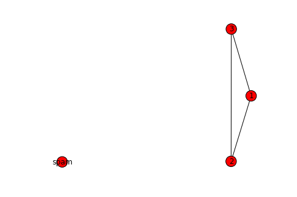

```python
import matplotlib.pyplot as plt
%matplotlib inline
plt.figure(figsize=(6,4))
nx.draw(G)
plt.show()
# plt.savefig("path.png")
```